# Ghost Crab Analysis

## Concept

- Ghost crab populations strongly decline under high human disturbance
  - Population size was a good indicator of effective beach management
- Are ghost crab burrows also a good indicator effective beach management?

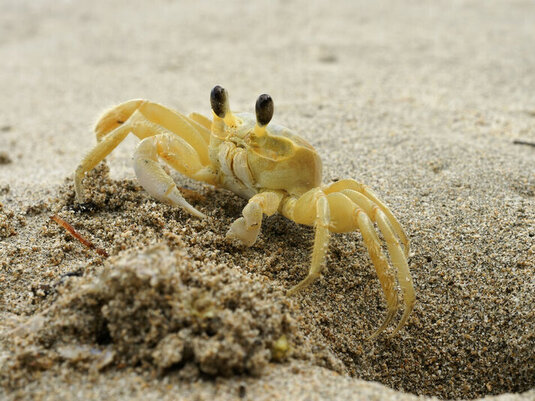

## Project Goals

1. Analyze ghost crab burrow [data](https://doi.org/10.6084/m9.figshare.6895109)
   - Collected in South Carolina between May and Sept. of 2016
2. Determine if there is a correlation between burrow dimensions and human disturbance
3. Present findings in a way that is understandable

## Required Packages

- Tidyverse
- Magrittr
- Knitr

## Importing Data

Data used in analysis comes from three datasets:

1. [Burrow size among impact types](https://figshare.com/articles/Impacts_of_human_disturbance_on_ghost_crab_burrow_morphology_and_distribution_on_sandy_shore/6895109/1?file=12581102)
2. [Burrow density among impact types](https://figshare.com/articles/Impacts_of_human_disturbance_on_ghost_crab_burrow_morphology_and_distribution_on_sandy_shore/6895109/1?file=12581114)
3. [Burrow architecture](https://figshare.com/articles/Impacts_of_human_disturbance_on_ghost_crab_burrow_morphology_and_distribution_on_sandy_shore/6895109/1?file=12581108)

[figure not shown]

## Important Information

Information needed to interpret graphs

Variables

- HI: High human impact
- HV: High human and vehicle impact
- MI: Moderate human impact
- P: Pristine sites (little to no human impact)

# Part I

Looking at human impact on burrow opening diameter

## Opening Diameter vs. Impact

Filtering and selecting data

| Site | Opening Diameter (mm) | Impact Type |
| --- | --- | --- |
| North Island 1 | 64.25 | P |
| Isle of Palm 1 | 61.50 | MI |
| Pawleys Island 2 | 57.45 | MI |
| North Island 2 | 57.14 | P |
| South Island 2 | 55.75 | P |
| Debidue Island | 52.41 | P |

## Opening Diameter vs. Impact

Graphing data

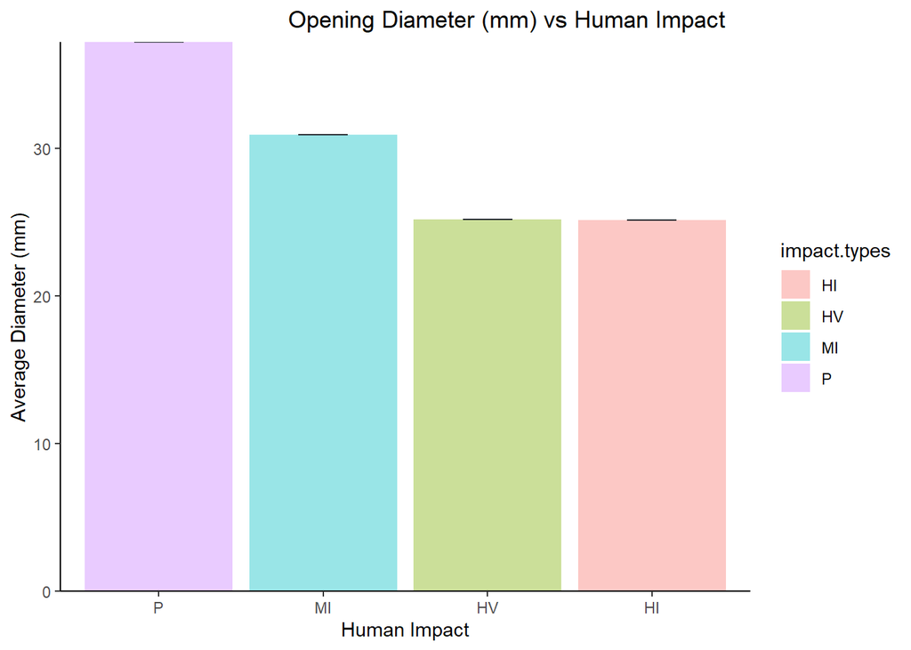

# Part II

Looking at human impact on burrow density

## Density vs. Impact

Filtering and selecting data

| Site | Impact Type | Burrow Density m^-2 |
| --- | --- | --- |
| North Island 1 | P | 1.46 |
| South Island 2 | P | 1.38 |
| North Island 1 | P | 1.36 |
| South Island 1 | P | 1.34 |
| Debidue Island | P | 1.20 |
| South Island 1 | P | 1.20 |

## Density vs. Impact

Graphing data

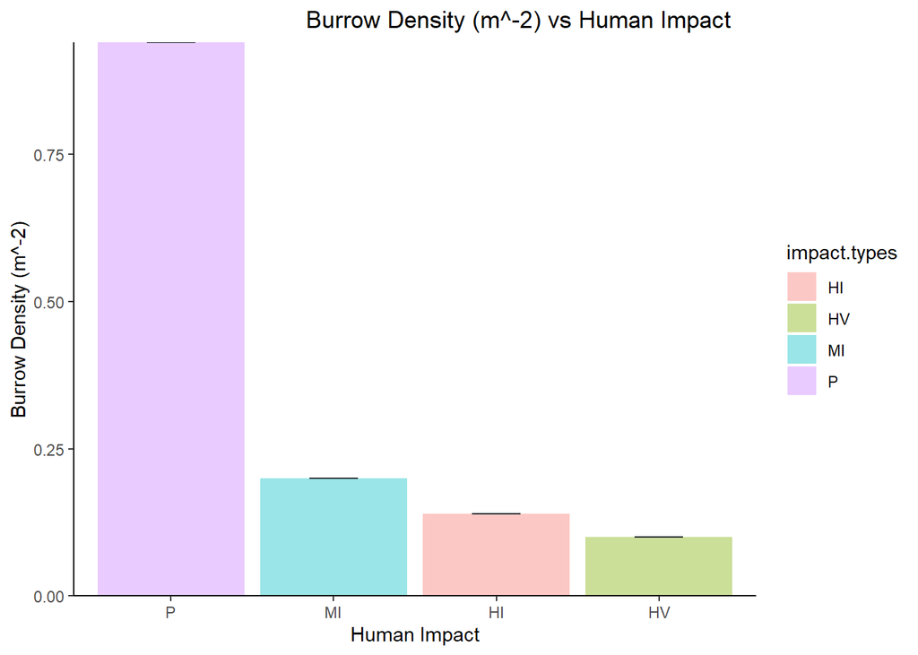

# Part III

Looking at human impact on burrows as they get closer to human development

## Burrow Size vs. Quadrat

Graphing data

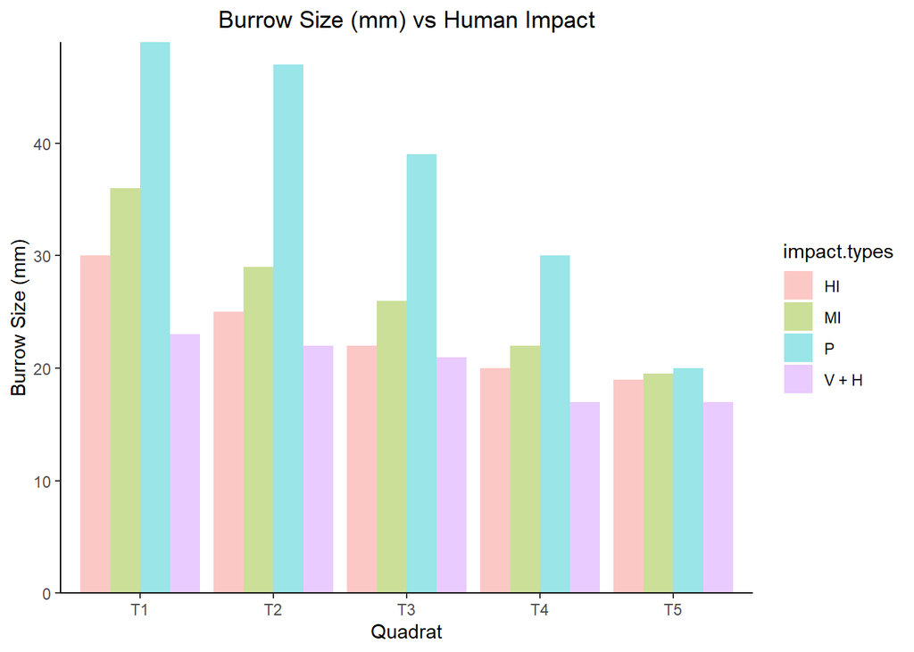

## Burrow Density vs. Quadrat

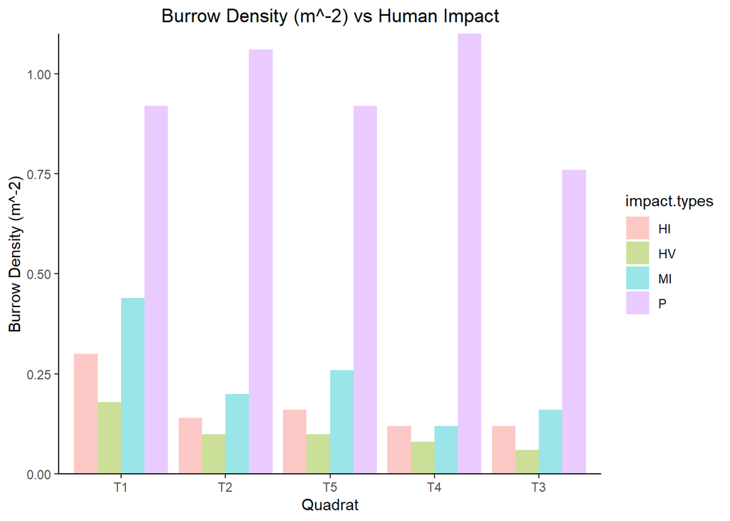

# Conclusion

What can we conclude based off these graphs?

## Conclusion

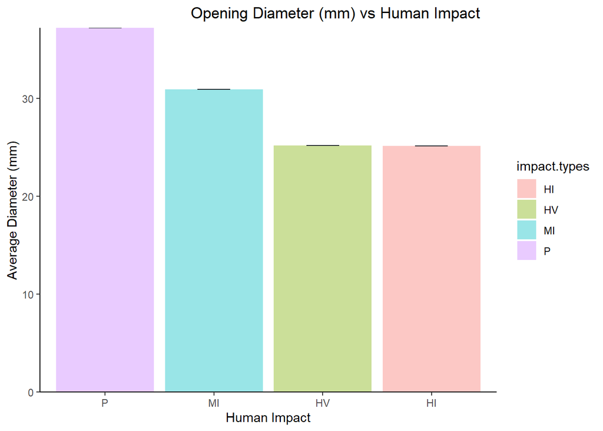

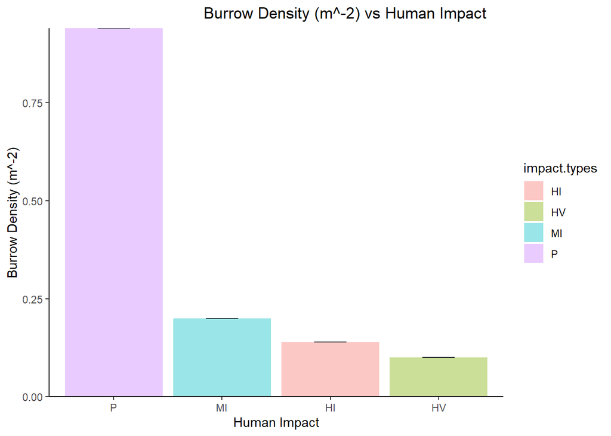

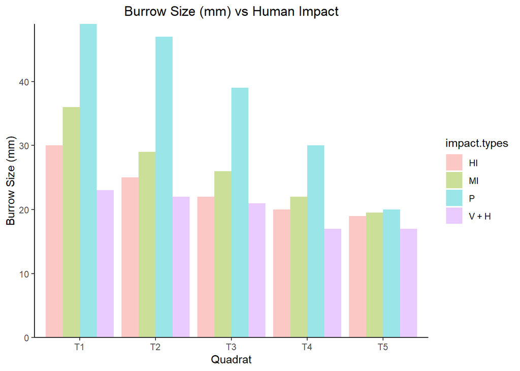

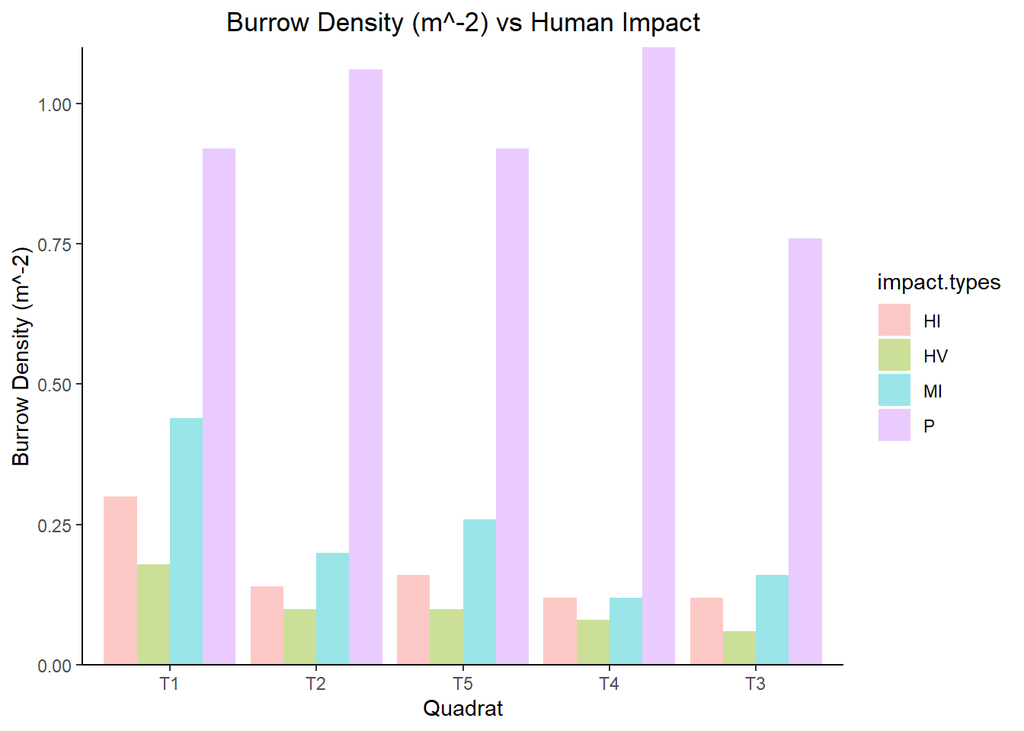

## Conclusion

1. Even small human impacts can cause a change in ghost crab burrow dimensions
2. This burrowing behavior change makes studying Ghost Crab burrows an effective determinant of beach management

# Questions?

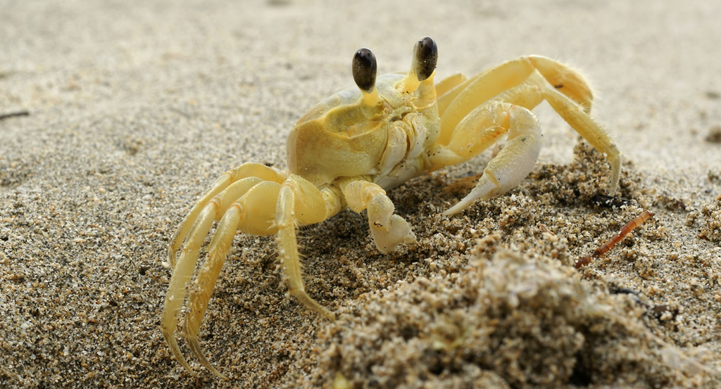